# Statistics for MSc

Dr Polla Fattah

2025-04-15

# 1. Introduction: Why Statistics in Research?

## 1.1 The Role of Statistics in Computer Science Research

In computer science, especially at the postgraduate level, **research goes beyond building systems**. It must involve **evaluating, validating, and communicating** those systems’ effectiveness using data.

This is where **statistics becomes essential**.

### Key Questions Every Researcher Must Answer:

- *Does my algorithm really perform better than others?*
- *How confident can I be in my results?*
- *Is the difference I observed due to chance, or is it meaningful?*
- *How do I report my findings objectively?*

Statistics provides the **language of evidence** in science. It transforms raw performance numbers into **scientifically defensible claims**.

### 1.2 Why Postgraduates Can’t Ignore Statistics

In computer science research, especially at the postgraduate level, **an observation alone is not evidence**. Without statistical analysis, a claim such as:

> *“I ran my new sorting algorithm and it seemed faster than QuickSort.”*

is anecdotal at best. It lacks the rigor required for scientific validation.

In a thesis defense, such a statement will immediately prompt scrutiny. Examiners are trained to ask questions like:

- How many times did you test each algorithm?
- What was the average execution time?
- How consistent were the results?
- Could the difference be explained by random variation?
- Did you use different datasets or input sizes?
- Have you demonstrated that the difference is statistically significant?

These are not simply technical questions — they are **statistical questions**. Without a solid understanding of statistical tools, it is difficult to answer them convincingly.

In short, **statistics is what transforms a set of observations into a defensible research finding**. It allows you to quantify uncertainty, test assumptions, justify claims, and communicate results clearly — all of which are essential for academic credibility.

## 1.3 Statistics in Experimental Design and Validation

In computer science research, statistical methods are used for:

| Research Activity | Statistical Role |
| --- | --- |
| Algorithm performance comparison | t-tests, ANOVA, boxplots |
| Classifier accuracy evaluation | Confidence intervals, hypothesis testing |
| Survey analysis | Chi-squared tests, proportions, ranking |
| Input/output performance modeling | Regression, correlation |
| Software/system reliability | Error rate analysis, standard deviation |

## 1.4 Our Guiding Scenario: The Algorithm Showdown

To make the statistical concepts in this lecture more tangible and relevant to your experience as a postgraduate student, we will return repeatedly to a **single research scenario** — one that resembles the kind of problem you might actually face in your thesis.

### The Scenario

> **You are defending your MSc thesis in Computer Science.**  
> Your research investigates the performance of two well-known sorting algorithms:  
> **MergeSort** and **QuickSort**.

You claim that **MergeSort is more efficient**, and you want to prove this claim **based on experimental data**.

### The Experiment

To support your hypothesis, you design a controlled experiment:

- You run each algorithm **30 times** on large, randomly generated datasets.
- You record the **execution time in milliseconds** for every trial.
- You maintain consistent conditions across runs to ensure fairness.

## 2.1 Introducing the Hypothetical Experiment

To demonstrate statistical concepts in this lecture, we will simulate a **controlled experiment** involving two sorting algorithms: **MergeSort** and **QuickSort**.

You are a postgraduate student evaluating the performance of these algorithms for your thesis. You want to answer the research question:

> *Is MergeSort significantly faster than QuickSort on average?*

To explore this, you conduct the following experiment:

- You run **MergeSort** and **QuickSort** on the same large dataset.
- Each algorithm is executed **30 times**.
- You record the **execution time in milliseconds** for each run.

These measurements will form the basis of our statistical analysis throughout the lecture.

We use the a random function to simulate realistic, normally distributed data with slight differences in mean and variability.

| Run | QuickSort (ms) | MergeSort (ms) |
| --- | --- | --- |
| 1 | 60.23 | 50.28 |
| 2 | 48.61 | 51.52 |
| 3 | 54.18 | 53.18 |
| 4 | 55.80 | 44.96 |
| 5 | 54.43 | 50.52 |
| 6 | 51.36 | 39.41 |
| 7 | 61.07 | 44.08 |
| 8 | 51.43 | 43.75 |
| 9 | 64.11 | 35.93 |
| 10 | 51.62 | 48.18 |
| 11 | 59.83 | 49.03 |
| 12 | 65.72 | 46.19 |
| 13 | 43.67 | 51.79 |
| 14 | 50.33 | 44.37 |
| 15 | 51.20 | 41.16 |
| 16 | 55.82 | 50.16 |
| 17 | 50.29 | 43.94 |
| 18 | 36.06 | 55.22 |
| 19 | 37.36 | 45.84 |
| 20 | 59.92 | 51.28 |

**Note on Data Format:** While the table above shows the data in a **wide format** (QuickSort and MergeSort side-by-side) for clarity, our actual dataset is stored in **long format**.

This allows us to easily calculate group-wise statistics, create plots, and run statistical tests using tidy R tools such as `t.test()`, `aggregate()`, and `ggplot2`, that we will learn about them later in this lecture. So the data is actaully in this format

```r
print(head(algo_data))
```

```
##   Algorithm  Time_ms
## 1 QuickSort 60.22575
## 2 QuickSort 48.61181
## 3 QuickSort 54.17877
## 4 QuickSort 55.79718
## 5 QuickSort 54.42561
## 6 QuickSort 51.36325
```

This dataset contains: - A column `Algorithm` indicating which sorting algorithm was used  
- A column `Time_ms` representing the measured execution time for that run

You now have a clean and realistic dataset with which to explore: - Measures of central tendency and spread  
- Visualizations  
- Assumption checking  
- Confidence intervals  
- Hypothesis testing

### The Core Research Question

The central question you aim to answer is:

> *“Is MergeSort significantly faster than QuickSort?”*

To answer this convincingly, you cannot rely on visual inspection or gut feeling. You must:

- Summarize the data with appropriate statistics
- Visualize distributions and check for skewness or outliers
- Verify statistical assumptions
- Calculate confidence intervals
- Perform hypothesis testing
- Communicate your findings in a clear, objective, and statistically sound manner

In other words, your thesis defense becomes a **statistical investigation** — one in which every concept we learn will help you build a scientifically credible argument.

## 1.5 What You Will Learn in This Lecture

By the end of this crash course, you will be able to:

- **Describe and interpret key statistical concepts**, including mean, median, variance, and standard deviation
- **Summarize and visualize data** using appropriate tools such as histograms, boxplots, and scatterplots
- **Assess the distribution of data**, including symmetry, skewness, and normality assumptions using QQ plots and statistical tests
- **Quantify uncertainty** through the construction and interpretation of confidence intervals
- **Perform and interpret statistical comparisons**, including t-tests, ANOVA, and their non-parametric alternatives
- **Analyze categorical variables** using chi-squared tests for goodness-of-fit and independence
- **Understand and apply hypothesis testing**, including p-values, significance levels, and effect size
- **Present and defend statistical findings** clearly and rigorously in the context of a research thesis

# 2. Summarizing Data: Center and Spread

## 2.1 Central Tendency

When analyzing data, one of the first questions we often ask is:

> “Where is the center of the data?”

**Central tendency** refers to the concept of a typical or central value around which data tend to cluster. It is a foundational idea in statistics, providing a **numerical summary of an entire dataset** using a single value.

The three most common measures of central tendency are:

- **Mean**: the arithmetic average
- **Median**: the middle value
- **Mode**: the most frequently occurring value

Each has strengths and weaknesses depending on the **shape** and **nature** of the data.

#### The Mean (Arithmetic Average)

The **mean** is the sum of all values divided by the number of values:

$$\bar{x} = \frac{1}{n} \sum_{i=1}^{n} x_i$$

It is widely used due to its simplicity and because many statistical techniques are based on it. However, the mean is **sensitive to outliers**. A single extreme value can distort the result significantly.

**Example**: If most run-times are around 50ms, but one test took 200ms due to a system hiccup, the mean will be pulled upward.

#### The Median (Middle Value)

The **median** is the middle value when all observations are ordered. If the number of observations is even, it is the average of the two middle values.

It is **not affected by outliers**, which makes it a more robust indicator of central tendency in **skewed distributions**.

**Example**: In the presence of an unusually long run-time in a generally stable set of results, the median may reflect the “typical” behavior more faithfully than the mean.

#### The Mode (Most Frequent Value)

The **mode** is the value that appears most frequently in a dataset.

- In continuous numerical data, the mode is often not informative or may not exist.
- In categorical or ordinal data (e.g., UI preference: A, B, or C), the mode becomes much more useful.

### Calculating Central Tendency

Let’s use our experimental dataset comparing QuickSort and MergeSort execution times.

```r
mean(algo_data$Time_ms)      # Overall mean
```

```
## [1] 49.90099
```

```r
median(algo_data$Time_ms)    # Overall median
```

```
## [1] 50.28587
```

```r
# Mode is not defined directly for continuous data, but we can approximate:
table(round(algo_data$Time_ms))  # Frequency table of rounded values
```

```
##
## 33 36 37 39 41 44 45 46 48 49 50 51 52 53 54 55 56 59 60 61 63 64 66
##  1  2  1  1  3  6  1  2  4  5  7  8  3  1  2  2  3  1  3  1  1  1  1
```

### Interpretation in a Research Context

When preparing your thesis: - Use the **mean** if your data are **normally distributed** and free of outliers. - Use the **median** if your data are **skewed** or contain outliers. - Use the **mode** only for **categorical or ordinal variables**.

Try to pair numerical summaries with **visualizations** to get a fuller picture.

## 2.2 Understanding Variability

While central tendency tells us *where* the data are centered, it does not tell us *how spread out* the values are around that center. In research, especially in performance analysis, knowing whether values are **consistently close to the mean** or **widely scattered** is crucial.

Variability measures help us quantify **how much uncertainty or inconsistency** exists in our data.

In this section, we will introduce four core concepts:

- **Range**
- **Deviation from the mean**
- **Variance**
- **Standard deviation**

Each concept builds upon the previous, leading to a deeper understanding of the data’s behavior.

### 2.2.1 Range

The **range** is the simplest measure of spread:

$$\text{Range} = \text{Maximum} - \text{Minimum}$$

It gives the full span of values but is **very sensitive to outliers**, since it depends only on the two extreme points.

```r
range(algo_data$Time_ms)
```

```
## [1] 33.03455 65.71987
```

```r
diff(range(algo_data$Time_ms))  # Actual range value
```

```
## [1] 32.68532
```

This tells us the **total spread** of execution times across both algorithms. However, it does not tell us how values are distributed within this range.

### 2.2.2 Deviations from the Mean

To get a deeper sense of spread, we consider how far each observation is from the mean:

$$x_i - \bar{x}$$

Where: - $x_i$ is each value - $\bar{x}$ is the sample mean

These are called **deviations**. They reflect the distance between each value and the center of the distribution.

However, if we add all the deviations, they **sum to zero** due to symmetry:

```r
mean(algo_data$Time_ms)
```

```
## [1] 49.90099
```

```r
sum(algo_data$Time_ms - mean(algo_data$Time_ms))  # Always zero
```

```
## [1] -6.394885e-14
```

This leads us to **square the deviations** to avoid cancellation — and that gives us the **variance**.

### 2.2.3 Variance (s²)

**Variance** is the average of the squared deviations from the mean:

$$s^2 = \frac{1}{n - 1} \sum_{i=1}^{n} (x_i - \bar{x})^2$$

- The numerator captures the **total squared deviation**
- Dividing by $n - 1$ (not $n$) corrects for bias — this is known as **Bessel’s correction**

```r
tapply(algo_data$Time_ms, algo_data$Algorithm, var)
```

```
## MergeSort QuickSort
##  27.56546  56.70344
```

Interpretation:  
Variance gives us a numerical sense of spread, but its unit is **squared**, making it harder to interpret directly (e.g., ms²).

### 2.2.4 Standard Deviation (SD)

The **standard deviation** is simply the **square root of the variance**:

$$s = \sqrt{s^2}$$

It expresses variability in the **same units as the original data**, making it far more interpretable.

```r
tapply(algo_data$Time_ms, algo_data$Algorithm, sd)
```

```
## MergeSort QuickSort
##  5.250282  7.530168
```

Interpretation:  
The standard deviation tells us, on average, **how far values deviate from the mean**. A higher SD indicates greater variability (i.e., less consistency), while a lower SD implies tighter clustering.

### 2.2.5 Visual Intuition for Spread

Let’s visually compare two distributions that have **the same mean**, but **different spreads**.

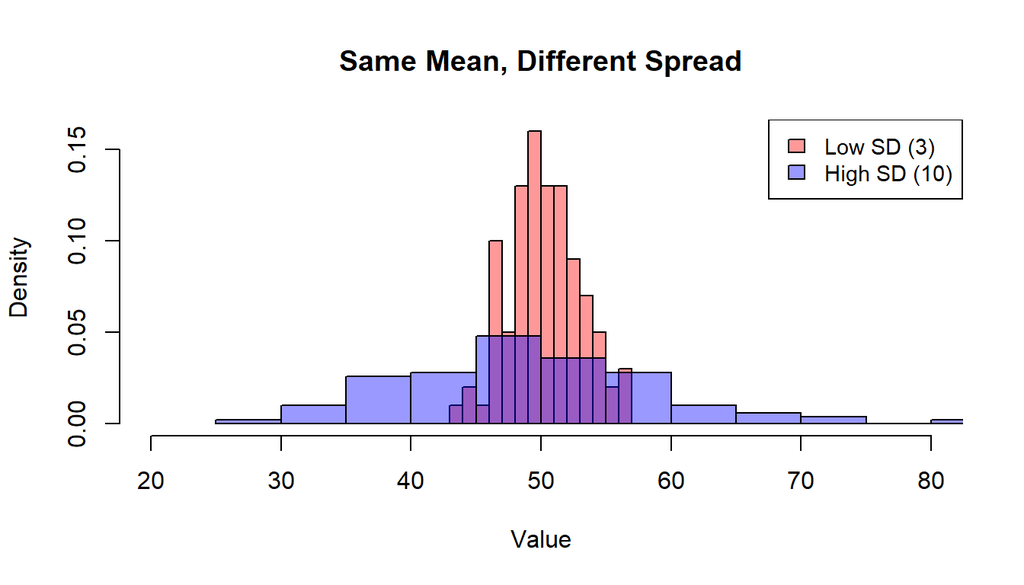

This illustrates: - **Higher SD** leads to a **wider, flatter** distribution - **Lower SD** results in a **narrower, more peaked** shape

Even with the **same average**, variability changes how reliable and predictable the data are.

## 2.3 Visualizing Distributions

While numerical summaries (like mean and standard deviation) are useful, they can sometimes hide important details about how data behave. **Visualizing the distribution** of your data allows you to:

- Detect **patterns**, **skewness**, or **outliers**
- Evaluate assumptions like **symmetry** and **normality**
- Compare distributions across groups
- Communicate findings more clearly to others

In this section, we will explore the two most important tools for visualizing distributions: - **Histograms** - **Boxplots**

We will also introduce supporting concepts: **quartiles**, **interquartile range (IQR)**, and **outlier detection**.

### 2.3.1 Histograms

A **histogram** shows how data are distributed across intervals (called *bins*). It answers the question:

> “How many values fall within each range of the variable?”

Each bar represents a range of values, and its height indicates how many observations fall within that range.

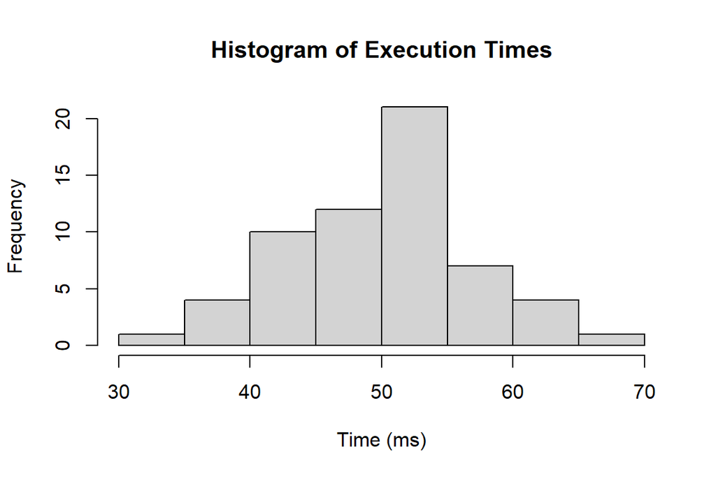

#### Why Use a Histogram?

- To see **how values are spread**
- To detect **skewness** or unusual peaks
- To explore whether the data look **normally distributed**
- To get a rough sense of **center and spread**

**Limitation**: Histograms don’t handle group comparisons well — for that, we need boxplots.

### 2.3.2 Understanding Quartiles and IQR

Before we explore boxplots, we must understand **quartiles**, which divide a dataset into four equal parts:

- **Q1 (25th percentile)**: 25% of data falls below this value
- **Q2 (50th percentile)**: the **median** of the dataset
- **Q3 (75th percentile)**: 75% of data falls below this value

The **interquartile range (IQR)** is defined as:

$$\text{IQR} = Q_3 - Q_1$$

It measures the **middle 50% of the data**, excluding extremes. It’s a robust alternative to standard deviation when data are skewed or contain outliers.

You can compute quartiles and IQR in R using:

```r
summary(algo_data$Time_ms)  # includes Q1, Median, Q3
```

```
##    Min. 1st Qu.  Median    Mean 3rd Qu.    Max.
##   33.03   45.62   50.29   49.90   53.43   65.72
```

```r
IQR(algo_data$Time_ms)
```

```
## [1] 7.805412
```

### 2.3.3 Boxplots: A Compact Summary of Distribution

A **boxplot** (or box-and-whisker plot) is a compact visual summary of the distribution of a variable. It is built on the five-number summary:

- **Minimum** (excluding outliers)
- **Q1** (25th percentile)
- **Median** (Q2, 50th percentile)
- **Q3** (75th percentile)
- **Maximum** (excluding outliers)

Additionally, boxplots **mark outliers** as individual points if they fall too far from the central range.

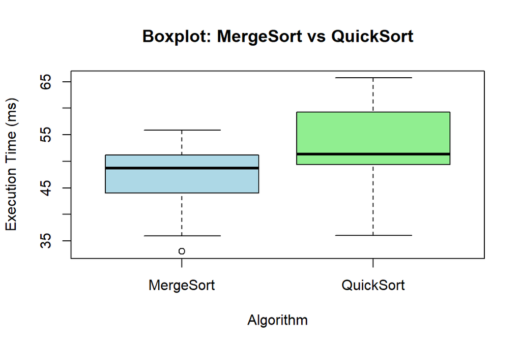

```r
boxplot(Time_ms ~ Algorithm,
        data = algo_data,
        col = c("lightblue", "lightgreen"),
        main = "Boxplot: MergeSort vs QuickSort",
        ylab = "Execution Time (ms)")
```

#### How to Interpret a Boxplot

- The **box** spans from **Q1 to Q3** — this is the IQR.
- The **line inside the box** shows the **median**.
- The **“whiskers”** extend to the minimum and maximum values **within 1.5 × IQR** from the box.
- **Points outside that range** are considered **outliers** and plotted individually.

#### Example: What the Boxplot Tells You

From the boxplot above, you can immediately tell:

- Which algorithm has a **lower median time**
- Which one has **more variability** (based on IQR and whisker length)
- Whether either algorithm has **outliers**
- Whether distributions are **symmetric or skewed**

For instance, a **longer upper whisker** or a **cluster of outliers on one side** may indicate **right skewness**.

### 2.3.4 Outliers and Skewness

Outliers are values that lie **far from the rest of the data**. In boxplots, a value is typically considered an outlier if it is:

$$\text{Less than } Q_1 - 1.5 \times IQR \quad \text{or} \quad
\text{Greater than } Q_3 + 1.5 \times IQR$$

Outliers may represent: - Data entry errors - Exceptional cases (e.g., performance spikes) - True variability

**Skewness**, on the other hand, refers to **asymmetry** in the distribution: - **Right-skewed**: long tail to the right - **Left-skewed**: long tail to the left

Both skewness and outliers affect the **choice of summary statistics** and influence which statistical tests are appropriate.

### 2.3.5 When to Use Each Visual

| Purpose | Use Histogram | Use Boxplot |
| --- | --- | --- |
| Understand overall shape | ✅ Yes | Limited |
| Detect skewness and modality | ✅ Yes | Partially |
| Compare multiple groups | ❌ Not easily | ✅ Very effective |
| See outliers | ❌ Not directly | ✅ Clearly marked |
| Visualize IQR and spread | ❌ No | ✅ Built-in |

# 3. Distributions and Statistical Assumptions

## 3.1 What Is a Distribution?

In statistics, a **distribution** describes how the values of a variable are spread or arranged across the number line. It shows the frequency (or probability) with which different values occur in a dataset or population.

Understanding distributions is fundamental to all of statistical reasoning, because many methods — such as confidence intervals, hypothesis testing, and model fitting — depend not only on the values themselves, but also on how those values are **distributed**.

### Conceptual Meaning

You can think of a distribution as a kind of **statistical fingerprint** for a variable. It tells us:

- Which values are **most common**
- Which values are **rare or extreme**
- Whether values are **symmetrically spread** around a center or skewed to one side
- Whether the data is **smooth and continuous** or **discrete and categorical**

Distributions can be **empirical** (based on observed data) or **theoretical** (based on probability models, like the normal distribution).

### Examples of Distribution Shapes

Let’s look at some common types of distributions seen in real-world and simulated data:

| Distribution Type | Description |
| --- | --- |
| **Uniform** | All values occur with equal frequency |
| **Normal (Gaussian)** | Symmetrical bell curve centered around the mean |
| **Right-skewed** | Long tail to the right (e.g., income, execution spikes) |
| **Left-skewed** | Long tail to the left (e.g., time-to-failure in some systems) |
| **Bimodal** | Two distinct peaks (e.g., mixture of two groups or processes) |
| **Multimodal** | More than two peaks — complex or overlapping subgroups |

These differences are **not cosmetic** — they **affect which summaries are meaningful** and **which tests are valid**.

### Discrete vs Continuous Distributions

Distributions can also be classified by the type of data they represent:

- **Discrete distributions** deal with countable values  
  Examples: number of users, frequency of clicks, days active  
  (e.g., Binomial, Poisson)
- **Continuous distributions** represent variables that can take on any value within a range  
  Examples: time, temperature, height, algorithm execution time  
  (e.g., Normal, Exponential)

Understanding whether your variable is discrete or continuous affects: - The choice of visualization (e.g., bar plot vs histogram) - The type of probability model to apply - The interpretation of statistical results

### Why Distributions Matter

Many statistical methods are based on **assumptions about the shape** of the distribution:

- The **t-test** assumes the sampling distribution of the mean is **normal**
- ANOVA assumes **normality within groups**
- Linear regression assumes **normality of residuals**

Violating these assumptions can lead to misleading conclusions.

Even more practically: distributional characteristics help you **choose the right summary statistics**, determine if your results are **reliable**, and communicate findings more effectively in your thesis or publication.

## 3.2 Symmetry, Modality, and Skewness

Once we understand what a distribution is, the next step is to describe its **shape**. This helps us decide which statistical summaries and tests are appropriate. Three of the most important shape-related features of a distribution are:

- **Symmetry**
- **Modality**
- **Skewness**

### 3.2.1 Symmetry

A distribution is **symmetric** if the left and right sides are roughly mirror images of each other when plotted.

- The **normal distribution** is a classic example of perfect symmetry.
- In symmetric distributions:
  $$\text{Mean} \approx \text{Median} \approx \text{Mode}$$

Symmetry is an important assumption behind many parametric statistical tests, such as t-tests and ANOVA.

### 3.2.2 Modality

**Modality** refers to the number of “peaks” (modes) in a distribution.

| Term | Meaning | Example Use Case |
| --- | --- | --- |
| **Unimodal** | One peak | Most natural or well-modeled measurements |
| **Bimodal** | Two distinct peaks | Two user populations, algorithm A vs B response |
| **Multimodal** | More than two peaks | Overlapping subpopulations or processes |

Understanding modality can reveal the presence of **mixture effects** in your data — for example, if your performance data includes **multiple system configurations**, it may produce multiple peaks.

### 3.2.3 Skewness

**Skewness** measures the **asymmetry** of a distribution.

- A distribution is **right-skewed (positively skewed)** if it has a long tail on the **right** side (high values).
  $$\text{Mean} > \text{Median} > \text{Mode}$$
- A distribution is **left-skewed (negatively skewed)** if it has a long tail on the **left** side (low values).
  $$\text{Mean} < \text{Median} < \text{Mode}$$

Skewness affects:

- Whether you should report the **mean or the median**
- Whether parametric methods are valid
- How you interpret outliers

### 3.2.4 Visualizing Shape

You can detect these features using **histograms**, **density plots**, or **boxplots**. Consider this example:

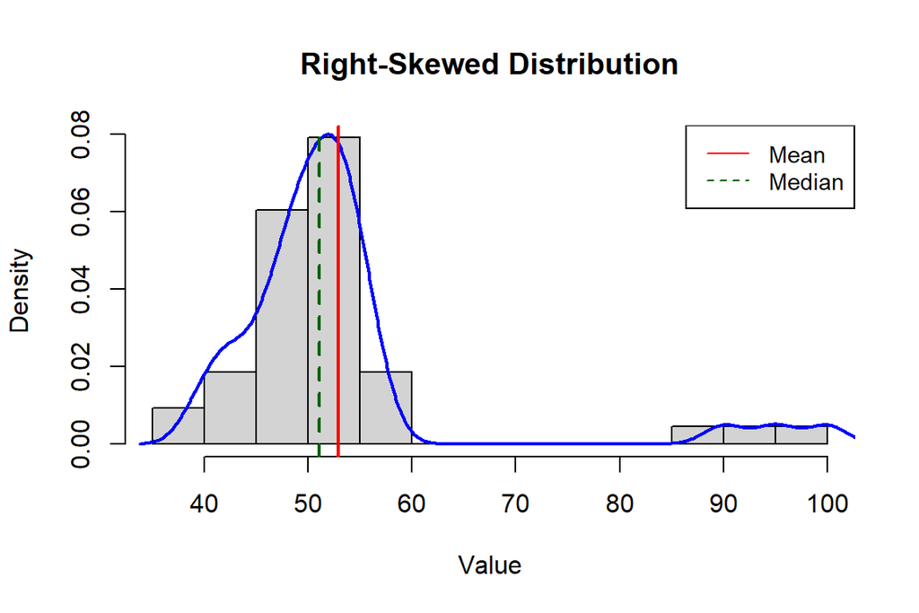

```r
set.seed(101)
right_skewed <- c(rnorm(40, mean = 50, sd = 5), 90, 95, 100)

hist(right_skewed, col = "lightgray", breaks = 12,
     main = "Right-Skewed Distribution", xlab = "Value", freq = FALSE)
lines(density(right_skewed), col = "blue", lwd = 2)
abline(v = mean(right_skewed), col = "red", lwd = 2, lty = 1)
abline(v = median(right_skewed), col = "darkgreen", lwd = 2, lty = 2)
legend("topright", legend = c("Mean", "Median"),
       col = c("red", "darkgreen"), lty = 1:2, cex = 0.9)
```

Notice how:

- The **mean is pulled right** by the outliers
- The **median stays closer to the center**
- The distribution is **not symmetric**

## 3.3 The Normal Distribution and the Empirical Rule

The **normal distribution**, also known as the **Gaussian distribution**, is one of the most important concepts in statistics. It serves as the **foundation** for many statistical methods, including t-tests, ANOVA, regression analysis, and confidence intervals.

Understanding its shape, properties, and implications is essential for interpreting statistical results correctly and deciding which methods are appropriate.

The normal distribution is a **continuous probability distribution** characterized by:

- A **bell-shaped curve** that is symmetric about its mean
- A **single peak** at the mean (unimodal)
- A mathematical formula involving the mean $\mu$ and standard deviation $\sigma$:

$$f(x) = \frac{1}{\sqrt{2\pi\sigma^2}} \cdot \exp\left(-\frac{(x -
\mu)^2}{2\sigma^2}\right)$$

Key properties:

- The **mean**, **median**, and **mode** are all close or equal.
- The curve is **perfectly symmetric** around the mean.
- The shape is determined entirely by the **mean (center)** and **standard deviation (spread)**.

### Bell Shape, Symmetry, and Central Location

Because of its symmetry:

- Half the values lie **below the mean**, and half **above**
- Most values cluster **near the mean**, and extreme values are rare
- The further from the mean, the **less likely** a value is to occur

In graphical terms, the curve starts low, rises to a peak at the mean, and then falls symmetrically.

### The Empirical Rule (68–95–99.7%)

The **empirical rule**, also known as the **68–95–99.7 rule**, is a convenient rule of thumb that describes how data are distributed around the **mean** in a **normal distribution**.

It tells us what **percentage of values** are expected to lie within **one, two, or three standard deviations** from the mean:

| Range | Coverage (Approx.) | Description |
| --- | --- | --- |
| Mean ± 1 SD | 68% of data | Most data are close to the center |
| Mean ± 2 SD | 95% of data | Almost all data fall here |
| Mean ± 3 SD | 99.7% of data | Extremely rare values fall beyond this |

Let’s say your algorithm’s run-time follows a normal distribution with:

- Mean execution time = **50 ms**
- Standard deviation = **5 ms**

Then:

- **68%** of run-times will fall between **45 ms and 55 ms**
- **95%** will fall between **40 ms and 60 ms**
- **99.7%** will fall between **35 ms and 65 ms**

This rule gives us a **baseline expectation** for where most of our data should fall. If we observe values **far outside these boundaries**, they may be considered **outliers**, errors, or rare events worth investigating.

This rule is foundational for:

1. **Understanding variability**
   - It shows how **standard deviation** translates into **practical ranges**
2. **Identifying outliers**
   - Observations beyond ±2 or ±3 SD are often flagged as **unusual**
3. **Constructing confidence intervals**
   - Later, when we calculate **95% confidence intervals**, we’ll use the idea that 95% of values fall within ±2 standard errors from the mean
4. **Standardized scoring (Z-scores)**
   - The empirical rule underpins tools like **Z-scores**, which tell us how far a data point is from the mean in units of standard deviation

### Visualizing the Empirical Rule

[figure not shown]

This diagram illustrates how data cluster around the mean and shows why standard deviation is such a meaningful measure of spread in normal data.

### Why the Normal Distribution Is Central to Statistics

The normal distribution plays a central role in statistics for several reasons:

1. **Theoretical Basis**  
   Many random phenomena (e.g., biological measurements, measurement errors, response times) tend to approximate a normal distribution in large samples.
2. **Analytical Convenience**  
   The properties of the normal distribution allow for **exact calculation of probabilities**, critical values, and thresholds.
3. **Foundation for Parametric Methods**  
   Methods like the t-test, regression, and ANOVA assume (either explicitly or via the Central Limit Theorem) that the sampling distribution is approximately normal.
4. **CLT Linkage**  
   Even if the **raw data** are not normal, the **sampling distribution of the mean** tends to be normal under certain conditions — a result known as the **Central Limit Theorem**, which we will discuss next.

### Applying the Empirical Rule to Your Data

```r
# Mean and SD by group
qs_mean <- mean(algo_data$Time_ms[algo_data$Algorithm == "QuickSort"])
qs_sd   <- sd(algo_data$Time_ms[algo_data$Algorithm == "QuickSort"])

ms_mean <- mean(algo_data$Time_ms[algo_data$Algorithm == "MergeSort"])
ms_sd   <- sd(algo_data$Time_ms[algo_data$Algorithm == "MergeSort"])

# Print them nicely
cat("QuickSort:  Mean =", round(qs_mean, 2), ", SD =", round(qs_sd, 2), "\n")
```

```
## QuickSort:  Mean = 52.41 , SD = 7.53
```

```r
cat("MergeSort:  Mean =", round(ms_mean, 2), ", SD =", round(ms_sd, 2), "\n")
```

```
## MergeSort:  Mean = 47.39 , SD = 5.25
```

### Interpreting the Results (MergeSort Example)

Suppose the output is (actual numbers may vary due to random generation):

[output not shown]

### Visualizing the Ranges

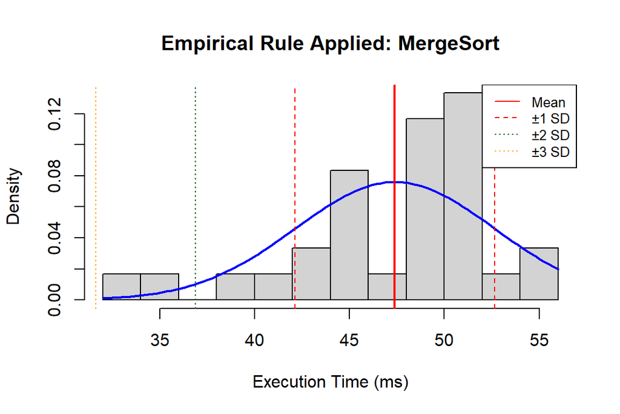

## 3.4 The Central Limit Theorem (CLT)

The **Central Limit Theorem (CLT)** is one of the most important and widely used results in all of statistics. It provides the **mathematical justification** for using methods like **t-tests** and **confidence intervals** even when the data **do not perfectly follow a normal distribution**.

It is often described as the bridge between **real-world data**, which can be messy or skewed, and **idealized statistical methods**, which often assume normality.

Suppose you repeatedly take samples from a population and compute the **mean of each sample**. The **distribution of these means** is called the **sampling distribution of the sample mean**.

The **Central Limit Theorem** says:

> As the sample size increases, the sampling distribution of the sample mean becomes **approximately normal**, regardless of the shape of the original population.

More formally:

- Let $x_1, x_2, \ldots, x_n$ be independent, identically distributed observations with mean $\mu$ and standard deviation $\sigma$.
- Then, the distribution of the sample mean $\bar{x}$ approaches a **normal distribution** as $n \to \infty$, with:

$$\bar{x} \sim \mathcal{N}\left(\mu, \frac{\sigma^2}{n}\right)$$

#### Why the CLT Matters

Many statistical techniques — such as **confidence intervals** and **t-tests** — assume normality. But in real-world research (including algorithm performance tests), the data may be **skewed**, **bimodal**, or contain **outliers**.

The CLT tells us:

- We do **not** need the raw data to be perfectly normal.
- We **can still use** parametric methods **if our sample size is large enough** (typically $n \geq 30$ is sufficient for the mean).

This is why CLT is especially important for **postgraduate research**: it justifies the methods you use, even when the data seem imperfect.

To simulate a non-normal population (e.g., a right-skewed exponential distribution), then repeatedly sample from it and observe the distribution of the sample means.

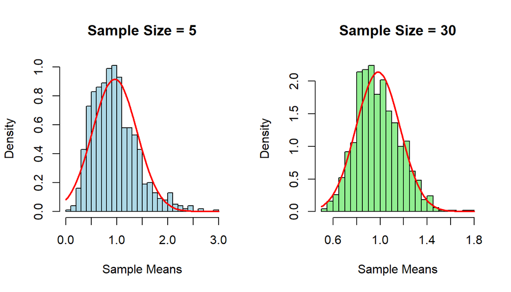

You should notice that:

- In the **first plot** (sample size = 5), the sampling distribution of the mean is still **somewhat skewed**
- In the **second plot** (sample size = 30), the distribution is **much more symmetric and bell-shaped**

This illustrates the core idea: **as sample size increases, the distribution of sample means becomes approximately normal**, even when the population is not.

## 3.5 Graphical Checks for Normality

Statistical methods such as **t-tests** and **confidence intervals** rely on the assumption that the underlying data (or at least the sampling distribution of the mean) is **approximately normal**.

While formal tests exist (like the Shapiro-Wilk test), it is **best practice to begin with graphical checks**. They provide intuitive insight into the shape, symmetry, skewness, and potential outliers in the data.

We will now use **actual data from our experiment** (MergeSort vs QuickSort) to demonstrate:

- **Histograms**
- **Density plots**
- **QQ plots (Quantile–Quantile plots)**

These will help answer the question:  
**Can we assume normality for each algorithm’s execution times?**

### 3.5.1 Histogram

A histogram shows the distribution of values across bins and helps detect **overall shape**.

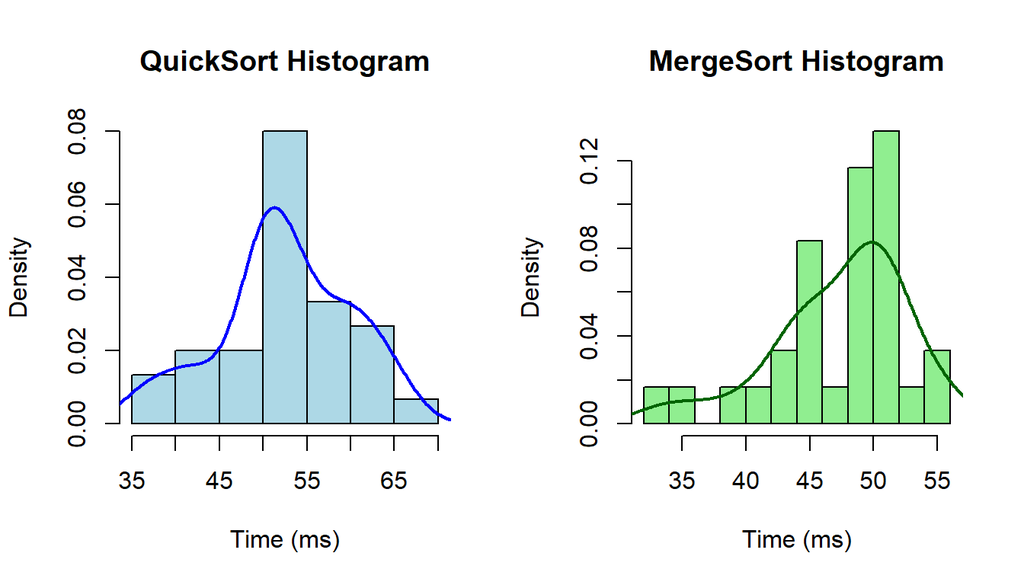

**How to interpret:**

- Check for **symmetry** — Is the curve roughly the same on both sides?
- Look for **peaks** — Is there one clear mode?
- Are there **long tails**? Skewed to the left or right?

### 3.5.2 Density Plots

A density plot gives a **smoothed estimate** of the distribution. This reduces noise and makes it easier to see skewness or irregularities.

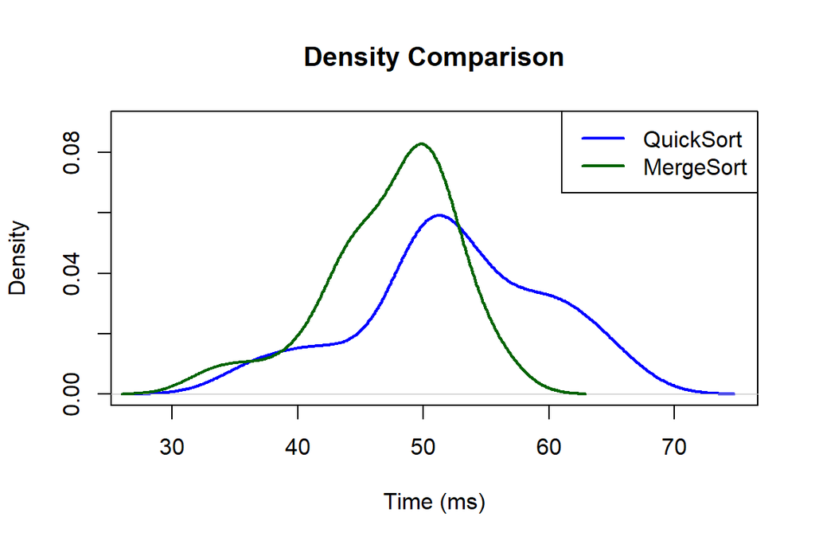

**How to interpret:**

- Do both curves look roughly **bell-shaped**?
- Is one clearly **skewed** compared to the other?
- Is the shape smooth and **unimodal**?

### 3.5.3 QQ Plots (Quantile–Quantile)

QQ plots compare your sample data’s quantiles to those of a **perfect normal distribution**. This is the **most reliable** visual check for normality in small samples.

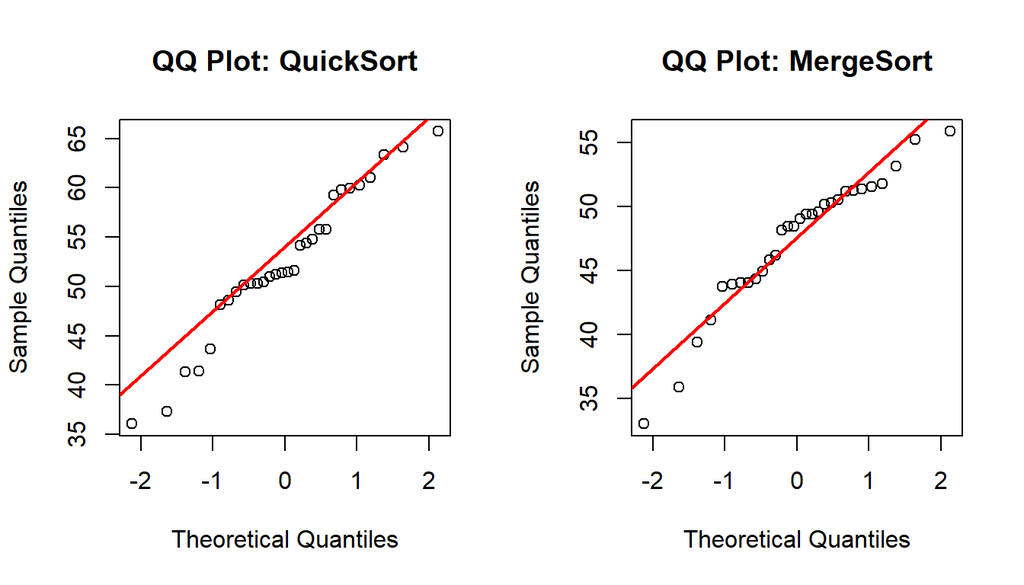

**How to interpret:**

- If points fall along the **diagonal line**, the data are approximately normal.
- **S-shaped curves** → skewness
- **Sharp bends** → outliers or heavy tails
- **Fan shapes** → unequal variance

### Summary

[output not shown]

Neither distribution is perfectly normal — and that’s expected. But **both are “normal enough”**, especially with **n = 30**, so we can **safely proceed with t-tests and confidence intervals** thanks to the **CLT**.

### When Can You Assume Normality? — A Practical Checklist

Use this guide when preparing to apply statistical tests that assume normality, such as **t-tests**, **ANOVA**, or constructing **confidence intervals**.

#### You Can Assume Normality If:

- Your sample size is **large enough** (usually **n ≥ 30**)  
  *The Central Limit Theorem ensures the sampling distribution of the mean will be approximately normal.*
- Your histogram or QQ plot looks **reasonably symmetric and bell-shaped**  
  *Minor skewness or irregularities are acceptable in large samples.*
- There are **no extreme outliers** that dominate the shape of the distribution  
  *Outliers may distort results more than skewness.*
- You ran a **normality test** (e.g., **Shapiro-Wilk**) and the p-value is **greater than 0.05**  
  *This suggests the data are not significantly different from a normal distribution.*

#### Be Cautious If:

- Sample size is **small (n < 30)** and the data appear **heavily skewed**
- Outliers are present that could influence the mean
- Your variable is not continuous (e.g., it’s ordinal or categorical)

#### lternative Option:

If normality cannot be assumed, consider **non-parametric tests**, such as:

- **Mann–Whitney U test** (instead of a two-sample t-test)
- **Wilcoxon signed-rank test** (instead of a paired t-test)
- **Kruskal–Wallis test** (instead of one-way ANOVA)

### 3.6 Formal Test: Shapiro–Wilk Normality Test

While visual tools like histograms and QQ plots give an intuitive sense of distribution shape, statistical analysis also benefits from a **formal test of normality**. One of the most commonly used tests for this purpose is the **Shapiro–Wilk test**.

It is particularly useful for **small to medium-sized datasets**, and it’s widely supported in statistical software like R.

#### How the Shapiro–Wilk Test Works (Conceptually)

The Shapiro–Wilk test evaluates whether your data could reasonably come from a **normal distribution**. It does so by:

1. **Comparing the order statistics** (i.e., sorted data points) of your sample to what would be expected from a normal distribution.
2. Calculating a test statistic $W$, which measures **how close the sample distribution is to a normal curve**.

If your data are very different from normal (e.g., heavily skewed, multimodal), the test will yield a **small W value** and a **low p-value**.

#### Hypotheses of the Shapiro–Wilk Test

Like most tests, the Shapiro–Wilk test is built on **null and alternative hypotheses**:

- **Null hypothesis (H₀):** The data come from a normal distribution.
- **Alternative hypothesis (H₁):** The data do not come from a normal distribution.

This means the **p-value** tells us how likely it is to see the given data **if the population were normal**.

#### Interpreting the P-Value

- If **p > 0.05**, we **do not reject H₀**:  
  → The data **could be normal** (normality is plausible).
- If **p < 0.05**, we **reject H₀**:  
  → The data are **significantly non-normal**.

> ⚠️ Important: A high p-value does **not** prove that the data *are* normal — it only means we don’t have strong evidence against normality.

#### Applying the Shapiro–Wilk Test to Your Data

Let’s run the test for **MergeSort** and **QuickSort** execution times.

```r
qs_data <- algo_data$Time_ms[algo_data$Algorithm == "QuickSort"]
ms_data <- algo_data$Time_ms[algo_data$Algorithm == "MergeSort"]

shapiro.test(qs_data)
```

```
##
##  Shapiro-Wilk normality test
##
## data:  qs_data
## W = 0.96209, p-value = 0.35
```

```r
shapiro.test(ms_data)
```

```
##
##  Shapiro-Wilk normality test
##
## data:  ms_data
## W = 0.93428, p-value = 0.06386
```

Sample output:

[output not shown]

- Both p-values are **greater than 0.05**.
- Therefore, we **fail to reject the null hypothesis** for both groups.
- This means the data **do not significantly deviate from normality**, and it’s reasonable to proceed with parametric tests.

#### Limitations of the Shapiro–Wilk Test

- **Very sensitive to sample size**:
  - In **large samples**, even small deviations from normality may result in significant p-values.
  - In **small samples**, the test may **not detect real skewness** due to low power.
- Should **always be used alongside visual tools** (histograms, QQ plots, density plots).
- The test **only assesses normality** — it does not check for **equal variances**, **independence**, or other assumptions of statistical tests.

# 4. Confidence Intervals and Statistical Inference (Expanded)

## 4.1 What Is a Confidence Interval?

A **confidence interval (CI)** is a range of values, calculated from sample data, that is likely to contain the **true population parameter** — such as a mean, proportion, or difference in means.

> It reflects both the **sample estimate** and the **uncertainty** due to sampling variation.

It means:  
We are 95% confident that the **true difference** in performance lies somewhere between **1.6 and 8.4 milliseconds** in favor of MergeSort.

## 4.2 What Does “95% Confidence” Actually Mean?

This is often misunderstood, so let’s be precise.

A **95% confidence interval** does *not* mean that there is a 95% chance the true value is in this particular interval.

Instead:

> If we repeated the same experiment **100 times**, and calculated a confidence interval from each sample, we expect **95 of those intervals** to contain the **true population parameter**.

The “95%” refers to the **long-run success rate of the method**, not the probability of the truth being in one interval.

## 4.3 Standard Error vs Confidence Interval

A common confusion in thesis writing is using **mean ± standard error** (SE) and assuming it’s a confidence interval. It is not.

Here’s the difference:

- **Standard Error (SE)** tells you how much the **sample mean is expected to vary** from sample to sample.
  $$SE = \frac{s}{\sqrt{n}}$$
- A **Confidence Interval** uses the SE to define a **margin of error**:
  $$CI = \bar{x} \pm t \times SE$$
  where $t$ is the critical value from the **t-distribution** (e.g., ≈ 2 for 95%).

> Think of SE as the **raw uncertainty**, and the CI as a **range of plausible values**, based on how uncertain we are.

## 4.4 How to Compute Confidence Intervals in R

The easiest way to compute a CI is by using `t.test()`. Even if you don’t need the p-value, this function gives you:

- the **mean**
- the **standard error**
- the **confidence interval**

```r
qs_data <- algo_data$Time_ms[algo_data$Algorithm == "QuickSort"]
ms_data <- algo_data$Time_ms[algo_data$Algorithm == "MergeSort"]

qs_ci <- t.test(qs_data)$conf.int
ms_ci <- t.test(ms_data)$conf.int

cat("QuickSort CI:", round(qs_ci, 2), "\n")
```

```
## QuickSort CI: 49.6 55.22
```

```r
cat("MergeSort CI:", round(ms_ci, 2), "\n")
```

```
## MergeSort CI: 45.43 49.35
```

This will print something like:

[output not shown]

## 4.5 Visualizing Confidence Intervals

Visualizing uncertainty helps you and your audience understand how confident your estimates are.

The plot below shows the **mean execution time** for each algorithm, along with its **95% confidence interval**:

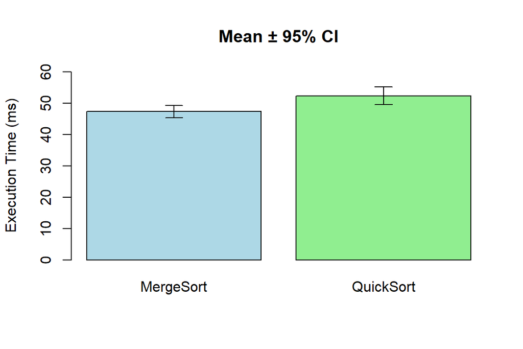

To interpret this plot:

- Taller bars = higher mean run-times
- Narrower error bars = more confidence (less uncertainty)
- Wider error bars = more variability in the data

## 4.6 What If the CI Includes Zero?

Sometimes we’re interested in the **difference** between two groups. For example:

> “Is MergeSort significantly faster than QuickSort?”

We can construct a CI for the **difference of means**:

```r
t.test(Time_ms ~ Algorithm, data = algo_data)$conf.int
```

```
## [1] -8.384496 -1.657631
## attr(,"conf.level")
## [1] 0.95
```

If the output is:

```
[1] -8.38 -1.66
```

This means:

- The **difference is statistically significant** (CI does *not* include 0)
- We are 95% confident that MergeSort is faster by **between 1.66 and 8.38 milliseconds**

However, if the CI had been something like:

```
[-1.23, 4.56]
```

Then:

- The CI **includes zero**
- We would say the data **do not provide strong evidence of a difference**
- This does **not mean the means are equal**, only that the data are **inconclusive**

# 5. Foundations of Hypothesis Testing

A **hypothesis** is a declarative statement that proposes a possible explanation or expected outcome based on prior knowledge or observation. It must be:

- **Testable**: Can be verified or refuted with data
- **Falsifiable**: Can be proven wrong through evidence
- **Specific**: Focused and clearly defined

Statistical analysis is not only about describing data — it’s about making **decisions** and **drawing conclusions** from it. When researchers ask questions like:

- *“Is this algorithm significantly faster?”*
- *“Does this new method improve accuracy?”*

## 5.1 Logic of Hypothesis Testing

Hypothesis testing is a formal procedure for evaluating a **research claim** using data. The logic is based on contradiction:  
We assume a **null hypothesis is true**, then test whether the observed data are **consistent or inconsistent** with that assumption.

If the data are **very unlikely** under the assumption, we **reject** it.

> In essence, hypothesis testing asks:  
> “If the null hypothesis were true, how likely is it that we’d see results like these?”

## 5.2 Types of Hypotheses

> The test evaluates whether the data provide enough evidence to **reject H₀** in favor of H₁.

We never “prove” H₁ directly — we either **reject** or **fail to reject** the null.

## 5.3 p-values and Statistical Significance

The **p-value** is the probability of obtaining results **as extreme or more extreme** than what we observed, **assuming H₀ is true**.

- A **small p-value** (typically less than 0.05) means the observed result is **unlikely** under H₀  
  → We **reject H₀** and say the result is **statistically significant**
- A **large p-value** means the observed result is **plausible** under H₀  
  → We **fail to reject H₀**

> A p-value is **not** the probability that H₀ is true.  
> It is the probability of seeing this data **if H₀ were true**.

### Example:

> A p-value of 0.03 means:  
> “If the algorithms had equal performance, we’d see this result (or something more extreme) only 3% of the time.”

## 5.4 Type I and Type II Errors

Statistical decisions are based on probabilities, not certainties — so **errors can occur**.

| Type | Description | Symbol | Example |
| --- | --- | --- | --- |
| **Type I Error** | Rejecting H₀ when it is actually true | $\alpha$ | Claiming MergeSort is faster when it isn’t |
| **Type II Error** | Failing to reject H₀ when it is false | $\beta$ | Failing to detect a real speed difference |

We control Type I errors by setting a **significance level** $\alpha$.  
We reduce Type II errors by increasing **sample size**, reducing variability, or using better tests.

## 5.5 One-Tailed vs Two-Tailed Tests

When formulating hypotheses, researchers must also decide **what kind of difference** they’re testing for.

### Use a one-tailed test only when:

- You have a **strong theoretical reason** to expect a specific direction
- The hypothesis was formulated **before seeing the data**

> Misusing one-tailed tests **after seeing the results** leads to bias and invalid conclusions.

## 5.6 The Significance Level (α)

The **significance level** $\alpha$ is the **threshold for decision-making**.

- Common choice: $\alpha = 0.05$
- This means we accept a **5% chance of making a Type I error**

If:

- **p ≤ α** → Reject H₀ → Result is **statistically significant**
- **p > α** → Do not reject H₀ → Result is **not statistically significant**

You may choose stricter levels (e.g., 0.01) when the consequences of a false positive are high (e.g., in medicine or critical systems).

## 5.7 Characteristics of a Good Hypothesis

A strong hypothesis:

1. **Is grounded in prior knowledge or observation**  
   – It should be informed by theory, literature, or empirical results.
2. **Clearly identifies the variables**  
   – What are you comparing or measuring?
3. **Is framed in a way that allows for statistical testing**  
   – For example, using terms like “greater than,” “different from,” or “associated with.”
4. **Uses operational definitions**  
   – Specifies how each variable will be measured or categorized.

### Examples of Research Questions vs. Hypotheses

| Research Question | Hypothesis (H₀ / H₁) |
| --- | --- |
| Is MergeSort faster than QuickSort on large inputs? | H₀: µ₁ = µ₂ (mean time is equal) |
|  | H₁: µ₁ < µ₂ (MergeSort mean time is less than QuickSort) |
| Does UI design affect user satisfaction? | H₀: No difference in satisfaction scores across designs |
|  | H₁: At least one design has a different mean satisfaction |
| Are male and female students equally likely to pass? | H₀: Pass rate is independent of gender |
|  | H₁: Pass rate depends on gender |

### Common Mistakes to Avoid

- **Vague language**: “Is there a correlation between these two things?” → Too broad
- **Non-testable claims**: “QuickSort is the best.” → How do you define “best”?
- **Lack of direction**: Directional hypotheses (greater than, less than) require justification and increase statistical power

### Why This Matters for Your Thesis

A well-formed hypothesis does more than guide analysis. It:

- Defines the scope of your experiment
- Helps you choose the right statistical test
- Frames your discussion and conclusions
- Gives clarity and credibility to your thesis defense

Later in this course, when we discuss hypothesis testing, p-values, and significance, you’ll see how **everything starts from how well the hypothesis was written**.

## 5.8 Summary of Hypothesis Terminologies

| Concept | Role in Hypothesis Testing |
| --- | --- |
| **H₀ / H₁** | Competing claims about population parameters |
| **p-value** | Probability of result under H₀ |
| **α level** | Cutoff for rejecting H₀ |
| **Significance** | Whether the result is unlikely under H₀ |
| **Type I / II errors** | Risks in decision-making |
| **Tail direction** | Determines how evidence is evaluated (1- vs 2-sided) |

# 6. Statistical Tests for Research

Now that we’ve covered how to formulate hypotheses, assess assumptions, and interpret confidence and significance, we are ready to explore the **core statistical tests** used in real-world research — especially in computer science and engineering contexts.

These tests allow researchers to formally answer questions such as:

- *Is one algorithm faster than another on average?*
- *Does performance vary across multiple systems or configurations?*
- *Are outcomes like success/failure dependent on experimental conditions?*
- *Are two variables related — and how strongly?*
- *What if the data violate parametric assumptions?*

## 6.1 t-Tests (Comparing Means)

The **t-test** is one of the most widely used statistical tests in scientific research. It allows us to compare **mean values** and determine whether the observed difference between them is **statistically significant**.

There are three main types of t-tests:

1. **One-sample t-test** — compares a sample mean to a known or hypothesized population mean
2. **Independent two-sample t-test** — compares the means of two independent groups
3. **Paired-sample t-test** — compares two related samples, such as before and after measurements on the same subjects

### Assumptions of the t-test

Before using any type of t-test, the following assumptions should be checked:

- **The data are numeric and continuous**
- **Observations are independent**
- The data are **approximately normally distributed** (especially important for small samples)
- For two-sample tests: **equal or unequal variances** should be considered

### 1. One-Sample t-test

**Use when**: You want to test whether a single sample mean differs from a known value (benchmark or theoretical mean).

#### Example Scenario:

> *“Does MergeSort have a mean execution time different from 50 milliseconds?”*

```r
ms_data <- algo_data$Time_ms[algo_data$Algorithm == "MergeSort"]

t.test(ms_data, mu = 50)
```

```
##
##  One Sample t-test
##
## data:  ms_data
## t = -2.7223, df = 29, p-value = 0.01085
## alternative hypothesis: true mean is not equal to 50
## 95 percent confidence interval:
##  45.42997 49.35095
## sample estimates:
## mean of x
##  47.39046
```

#### Interpretation:

- **Null hypothesis (H₀)**: mean = 50
- **Alternative hypothesis (H₁)**: mean ≠ 50 (two-tailed)

The test result includes: - Mean of the sample - t-statistic - p-value - Confidence interval for the mean

If the **p-value < 0.05**, we reject the null and conclude that the MergeSort mean time differs significantly from 50 ms.

### 2. Independent Two-Sample t-test

**Use when**: You want to compare the means of two unrelated groups.

#### Example Scenario:

> *“Is there a significant difference in mean execution time between MergeSort and QuickSort?”*

```r
t.test(Time_ms ~ Algorithm, data = algo_data, var.equal = FALSE)
```

```
##
##  Welch Two Sample t-test
##
## data:  Time_ms by Algorithm
## t = -2.9959, df = 51.806, p-value = 0.004192
## alternative hypothesis: true difference in means between group MergeSort and group QuickSort is not equal to 0
## 95 percent confidence interval:
##  -8.384496 -1.657631
## sample estimates:
## mean in group MergeSort mean in group QuickSort
##                47.39046                52.41152
```

#### Key points:

- This test assumes **independent samples**
- We set `var.equal = FALSE` by default (Welch’s t-test), which does **not assume equal variances**
- If p-value < 0.05, we reject the null hypothesis that the means are equal

#### Interpretation:

- **H₀**: µ₁ = µ₂ (same mean execution time)
- **H₁**: µ₁ ≠ µ₂ (different means)

This is the **most relevant test** for your central thesis question:  
> “Is MergeSort significantly faster than QuickSort?”

### 3. Paired-Sample t-test

**Use when**: You measure **two conditions on the same subjects** — for example, run both algorithms on the same inputs.

Let’s simulate that situation for illustration.

#### Simulated Example:

We pretend we used the **same 30 datasets** and ran both algorithms on each.

```r
set.seed(123)
input_ids <- 1:30
qs_times <- rnorm(30, mean = 52, sd = 6)
ms_times <- rnorm(30, mean = 48, sd = 5)

paired_data <- data.frame(
  Input = input_ids,
  QuickSort = qs_times,
  MergeSort = ms_times
)

t.test(paired_data$QuickSort, paired_data$MergeSort, paired = TRUE)
```

```
##
##  Paired t-test
##
## data:  paired_data$QuickSort and paired_data$MergeSort
## t = 2.001, df = 29, p-value = 0.05483
## alternative hypothesis: true mean difference is not equal to 0
## 95 percent confidence interval:
##  -0.06243577  5.71380733
## sample estimates:
## mean difference
##        2.825686
```

#### Interpretation:

- **H₀**: The average difference between paired samples = 0
- **H₁**: The average difference ≠ 0
- If p-value < 0.05, we conclude a significant difference in performance on the same inputs

## 6.2 ANOVA (Analysis of Variance)

While **t-tests** are ideal for comparing **two means**, many research questions in computer science involve **three or more groups**. In such cases, performing multiple t-tests increases the risk of **Type I error**. The solution is to use **ANOVA — Analysis of Variance**.

### What ANOVA Does

ANOVA tests whether there is a **statistically significant difference in means** across **multiple groups**, while maintaining control over the overall error rate.

> Instead of asking *“Which mean is different?”*, ANOVA first asks:  
> **“Is there *any* significant difference among the group means?”**

## 6.2.1 One-Way ANOVA

### When to Use

Use **one-way ANOVA** when:

- You have **one categorical factor** (e.g., Algorithm)
- You want to compare the **means across 3+ groups**

### Example Scenario

Let’s simulate a third sorting algorithm: **HeapSort**, and compare it alongside MergeSort and QuickSort using a one-way ANOVA.

### Simulate Data

```r
set.seed(2025)

qs <- rnorm(30, mean = 52, sd = 6)
ms <- rnorm(30, mean = 48, sd = 5)
hs <- rnorm(30, mean = 50, sd = 4.5)

algo3_data <- data.frame(
  Algorithm = rep(c("QuickSort", "MergeSort", "HeapSort"), each = 30),
  Time_ms = c(qs, ms, hs)
)
```

### Run One-Way ANOVA

```r
anova_model <- aov(Time_ms ~ Algorithm, data = algo3_data)
summary(anova_model)
```

```
##             Df Sum Sq Mean Sq F value  Pr(>F)
## Algorithm    2  408.2  204.12   7.499 0.00099 ***
## Residuals   87 2368.2   27.22
## ---
## Signif. codes:  0 '***' 0.001 '**' 0.01 '*' 0.05 '.' 0.1 ' ' 1
```

### Interpretation

- **H₀ (null hypothesis):** All algorithms have equal mean run-time
- **H₁ (alternative):** At least one algorithm has a different mean

If the **p-value < 0.05**, we reject the null and conclude that **there is a significant difference in performance** between at least two algorithms.

## 6.2.2 Post-Hoc Comparison: Tukey HSD

ANOVA tells us there is a difference — but not **which groups differ**. For that, we use **Tukey’s Honest Significant Difference (HSD)** test.

```r
TukeyHSD(anova_model)
```

```
##   Tukey multiple comparisons of means
##     95% family-wise confidence level
##
## Fit: aov(formula = Time_ms ~ Algorithm, data = algo3_data)
##
## $Algorithm
##                           diff        lwr      upr     p adj
## MergeSort-HeapSort  -0.9764591 -4.1886528 2.235735 0.7494717
## QuickSort-HeapSort   3.9499434  0.7377497 7.162137 0.0118579
## QuickSort-MergeSort  4.9264025  1.7142088 8.138596 0.0012577
```

This test compares **all pairs of algorithms** and adjusts for multiple testing. It shows: - Mean differences between groups - Confidence intervals - p-values adjusted for multiple comparisons

## 6.2.3 Visual Inspection: Boxplot

A boxplot can help visualize **group differences** and identify potential **outliers** or **skewness**.

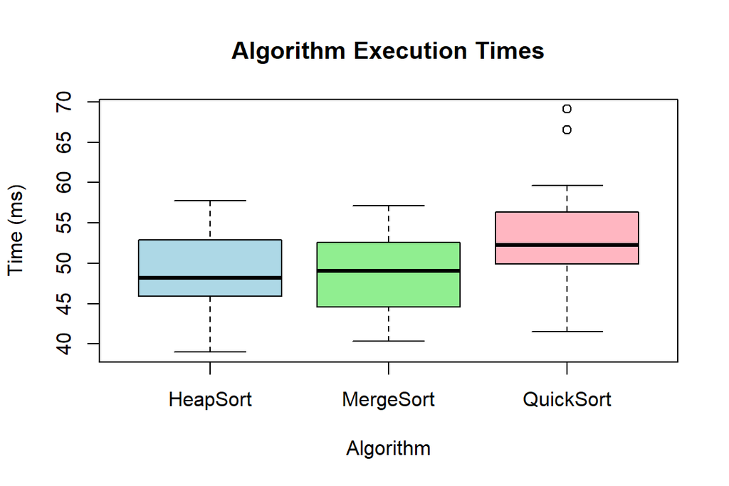

## 6.2.4 Assumptions of ANOVA

To ensure valid results, ANOVA relies on a few key assumptions:

| Assumption | How to Check |
| --- | --- |
| **Independence** | Data should be collected independently across groups |
| **Normality** | Each group’s data should be roughly normal → check with QQ plot or Shapiro-Wilk |
| **Homogeneity of variance** | Group variances should be similar → check with Bartlett or Levene test |

### Example: Check Homogeneity of Variance

```r
bartlett.test(Time_ms ~ Algorithm, data = algo3_data)
```

```
##
##  Bartlett test of homogeneity of variances
##
## data:  Time_ms by Algorithm
## Bartlett's K-squared = 1.3655, df = 2, p-value = 0.5052
```

If **p > 0.05**, the variances are not significantly different → good!

## 6.2.5 Two-Way ANOVA (with Interaction)

### When to Use

Use **two-way ANOVA** when:

- You have **two categorical factors**
- You want to test their **individual** and **combined** (interaction) effects

### Example Scenario

Suppose we test each algorithm on two types of datasets: **Small** and **Large** inputs.

```r
set.seed(123)

algo <- rep(c("QuickSort", "MergeSort", "HeapSort"), times = 30)
size <- rep(rep(c("Small", "Large"), each = 15), times = 3)
runtime <- rnorm(90, mean = ifelse(algo == "MergeSort", 48,
                              ifelse(algo == "QuickSort", 52, 50)) +
                       ifelse(size == "Large", 3, 0),
                sd = 4.5)

two_factor_data <- data.frame(
  Algorithm = algo,
  InputSize = size,
  Time_ms = runtime
)
```

### Run Two-Way ANOVA with Interaction

```r
two_way_model <- aov(Time_ms ~ Algorithm * InputSize, data = two_factor_data)
summary(two_way_model)
```

```
##                     Df Sum Sq Mean Sq F value   Pr(>F)
## Algorithm            2  477.3  238.67  14.485 3.94e-06 ***
## InputSize            1  142.4  142.44   8.645  0.00424 **
## Algorithm:InputSize  2    4.9    2.45   0.149  0.86182
## Residuals           84 1384.1   16.48
## ---
## Signif. codes:  0 '***' 0.001 '**' 0.01 '*' 0.05 '.' 0.1 ' ' 1
```

### Interpretation:

The model will test: - The **main effect** of Algorithm - The **main effect** of Input Size - The **interaction** between Algorithm × Input Size

> A significant interaction means the performance **difference between algorithms depends on input size**.

## Summary: ANOVA in Research

| Test | When to Use | What It Tells You |
| --- | --- | --- |
| **One-way ANOVA** | Compare ≥3 groups | Is there any difference among group means? |
| **Tukey HSD** | After ANOVA | Which groups differ from each other |
| **Two-way ANOVA** | Two factors (e.g., Algorithm × Size) | Main effects and interaction |
| **Assumption checks** | Before running ANOVA | Validates test reliability |

ANOVA provides a robust framework to test **complex experimental designs** — ideal for evaluating **multiple systems, configurations, or algorithms**.

## 6.3 Chi-Squared Tests (Categorical Data)

While t-tests and ANOVA are designed for **numerical data**, many research questions in computer science involve **categorical outcomes** — such as:

- Pass vs Fail
- Crashed vs Completed
- Preferred vs Not Preferred
- Small/Medium/Large classifications

To analyze such data, we use **Chi-Squared (χ²) Tests**, which allow us to evaluate whether **observed counts** differ from **expected counts** under a certain hypothesis.

### 6.3.1 Chi-Squared Goodness-of-Fit Test

**Use when**: You want to test whether **one categorical variable** fits an expected distribution.

#### Example Scenario

Suppose we test HeapSort on 60 datasets and record the number of **Successful** vs **Failed** runs. Based on theory, we expect a 95% success rate. Is the observed distribution consistent with that?

### Simulated Example

```r
# Observed outcomes: Success and Fail
observed <- c(Success = 54, Fail = 6)

# Expected probabilities: 95% success, 5% fail
expected_probs <- c(0.95, 0.05)
expected_counts <- sum(observed) * expected_probs

chisq.test(x = observed, p = expected_probs)
```

```
##
##  Chi-squared test for given probabilities
##
## data:  observed
## X-squared = 3.1579, df = 1, p-value = 0.07556
```

#### Interpretation:

- **H₀**: The observed proportions match the expected 95% / 5%
- **H₁**: The proportions differ significantly
- If p-value < 0.05, we reject H₀

### 6.3.2 Chi-Squared Test of Independence

**Use when**: You want to test whether **two categorical variables** are independent.

#### Example Scenario

You record the outcome (Success or Failure) of **each sorting algorithm** across 30 trials. Does algorithm choice affect outcome?

### Simulated Example

```r
set.seed(42)

algorithms <- rep(c("QuickSort", "MergeSort", "HeapSort"), each = 30)
# Simulate outcome: mostly successful, but vary by algorithm
outcomes <- c(
  sample(c("Success", "Fail"), 30, replace = TRUE, prob = c(0.93, 0.07)),
  sample(c("Success", "Fail"), 30, replace = TRUE, prob = c(0.98, 0.02)),
  sample(c("Success", "Fail"), 30, replace = TRUE, prob = c(0.90, 0.10))
)

cat_data <- data.frame(
  Algorithm = algorithms,
  Outcome = outcomes
)

# Create contingency table
table_data <- table(cat_data$Algorithm, cat_data$Outcome)
chisq.test(table_data)
```

```
##
##  Pearson's Chi-squared test
##
## data:  table_data
## X-squared = 9.6041, df = 2, p-value = 0.008213
```

#### Interpretation:

- **H₀**: Algorithm and Outcome are independent (no relationship)
- **H₁**: Algorithm and Outcome are dependent (performance depends on algorithm)
- A **significant p-value** suggests that the **type of algorithm affects the success rate**

### 6.3.3 Assumptions of the Chi-Squared Test

| Assumption | Explanation |
| --- | --- |
| **Expected counts ≥ 5** | Each cell in the contingency table should have at least 5 expected values |
| **Independent observations** | Each outcome should be from a distinct trial or unit |
| **Sufficient sample size** | Chi-squared tests are not reliable for very small datasets |

You can check expected counts directly:

```r
chisq.test(table_data)$expected
```

```
##
##                 Fail  Success
##   HeapSort  2.333333 27.66667
##   MergeSort 2.333333 27.66667
##   QuickSort 2.333333 27.66667
```

If **any expected count < 5**, consider: - **Combining categories** - Using **Fisher’s Exact Test** (for 2×2 tables and small samples)

### Practical Relevance for Research

Chi-squared tests are ideal when analyzing: - **Error types** by method - **Crash rate** by platform - **Pass/fail rates** by algorithm - **Survey preferences** by demographic

These tests give categorical results **statistical grounding**, enabling you to support claims about relationships and proportions with confidence.

## 6.4 Correlation Analysis

**Correlation analysis** is used to determine whether two numeric variables **move together** — and if so, how **strongly** and in **what direction**.

In computer science research, this is useful when investigating relationships like:

- Input size vs execution time
- Error rate vs number of iterations
- User rating vs completion time
- Memory usage vs frame rate

However, it’s crucial to remember:  
> **Correlation measures association, not cause and effect.**

## 6.4.1 Pearson Correlation Coefficient (r)

### When to Use

- Both variables are **numeric** and **normally distributed**
- You suspect a **linear** relationship

### What It Measures

- Strength and direction of a **linear** relationship
- Values range from -1 to 1

| Value of r | Interpretation |
| --- | --- |
| +1 | Perfect positive linear correlation |
| 0 | No linear correlation |
| -1 | Perfect negative linear correlation |

### Example: Input Size vs Run Time

Let’s simulate a relationship between input size and algorithm run-time:

```r
set.seed(123)
input_size <- seq(100, 1000, length.out = 50)
qs_runtime <- 0.05 * input_size + rnorm(50, mean = 0, sd = 10)

cor(input_size, qs_runtime)  # Pearson correlation
```

```
## [1] 0.8185339
```

This computes the **Pearson correlation coefficient** between input size and QuickSort run time.

## 6.4.2 Spearman Rank Correlation (ρ)

### When to Use

- Variables are **ordinal**, **non-normally distributed**, or **non-linear but monotonic**
- Data contains **outliers** that distort Pearson correlation

### What It Measures

- Correlation of **ranks**, not raw values
- More robust to outliers and non-linearity

```r
cor(input_size, qs_runtime, method = "spearman")
```

```
## [1] 0.8128211
```

## 6.4.3 Scatterplots and Visual Diagnostics

Always pair correlation with a **scatterplot**. This helps:

- Spot non-linear patterns
- Detect outliers
- Confirm linear or monotonic trends

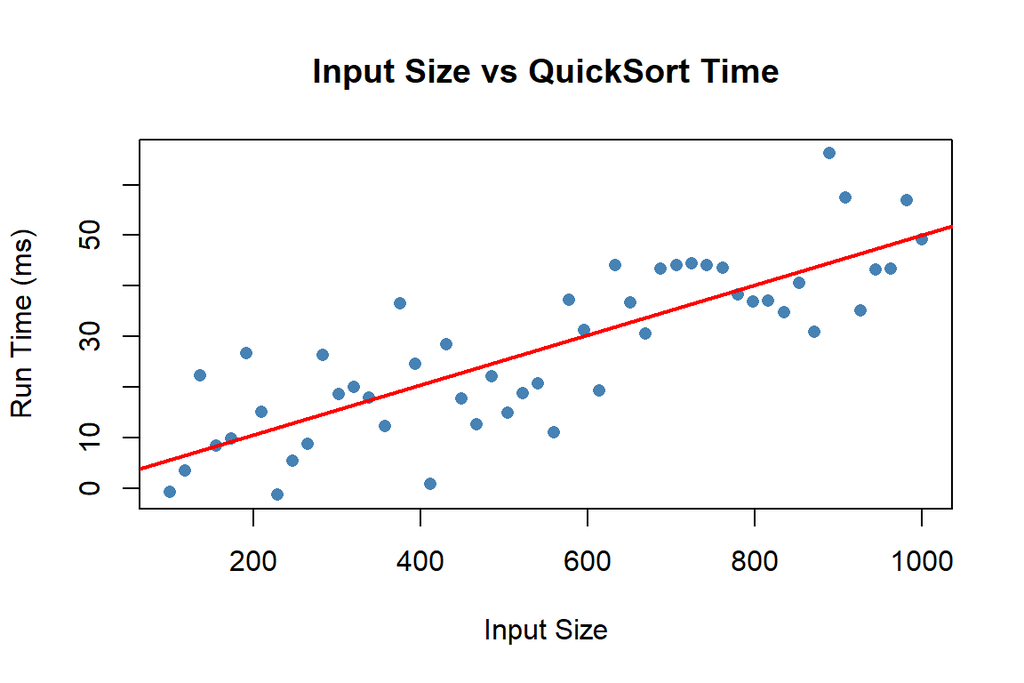

```r
plot(input_size, qs_runtime,
     main = "Input Size vs QuickSort Time",
     xlab = "Input Size", ylab = "Run Time (ms)",
     col = "steelblue", pch = 16)
abline(lm(qs_runtime ~ input_size), col = "red", lwd = 2)
```

You can also view relationships between multiple variables using a **correlation matrix**:

```r
df <- data.frame(
  Size = input_size,
  QuickSort = qs_runtime,
  Noise = rnorm(50),
  Quadratic = input_size^2 + rnorm(50, sd = 100)
)

round(cor(df), 2)
```

```
##           Size QuickSort Noise Quadratic
## Size      1.00      0.82  0.13      0.98
## QuickSort 0.82      1.00  0.09      0.81
## Noise     0.13      0.09  1.00      0.16
## Quadratic 0.98      0.81  0.16      1.00
```

This produces a matrix of correlation values for multiple numeric variables.

## 6.4.4 Correlation ≠ Causation

> A high correlation between A and B **does not imply** that A causes B.

Correlation may arise because: - A causes B  
- B causes A  
- A and B are both affected by a third variable (confounding) - It’s a coincidence (especially in small datasets)

Always interpret correlations **in context**, and support with theory or controlled experimentation.

## Summary

| Method | Use Case | Notes |
| --- | --- | --- |
| **Pearson** | Numeric, linear, normal | Most common for numeric variables |
| **Spearman** | Ordinal or monotonic | Robust to outliers and non-linearity |
| **Scatterplot** | Visual confirmation | Shows shape and outliers |
| **Correlation matrix** | Many variables | Explore pairwise relationships |

Correlation is a powerful **exploratory tool** — but not a substitute for **causal inference** or **experimental validation**.

## 6.5 Non-Parametric Alternatives

Not all datasets meet the **assumptions** required for parametric tests like t-tests and ANOVA. In particular:

- The data may be **non-normally distributed**
- There may be **outliers** or **skewness**
- Sample sizes may be **too small** to rely on the Central Limit Theorem
- The data may be **ordinal** or **ranked**, not continuous and numeric

In such situations, we turn to **non-parametric statistical tests**.

> These tests do **not assume normality** and are based on **ranks**, not actual values.

They are especially useful for: - Small sample sizes - Median comparisons - Ordinal (ranked) data - Robust testing in presence of outliers

## 6.5.1 Wilcoxon Signed-Rank Test (Paired Samples)

### When to Use

- Like a **paired t-test**, but for **non-normal** or **ordinal** paired data
- Measures whether the **median difference** between paired observations is zero

### Scenario

> You test QuickSort and MergeSort on **the same 30 datasets**, but suspect the differences aren’t normally distributed.

```r
set.seed(1)
qs_times <- rnorm(30, mean = 52, sd = 7)
ms_times <- rnorm(30, mean = 48, sd = 7)

# Apply Wilcoxon signed-rank test
wilcox.test(qs_times, ms_times, paired = TRUE)
```

```
##
##  Wilcoxon signed rank exact test
##
## data:  qs_times and ms_times
## V = 340, p-value = 0.02623
## alternative hypothesis: true location shift is not equal to 0
```

### Interpretation

- **H₀**: The median difference between paired groups is zero
- **H₁**: The median difference is not zero
- If **p < 0.05**, conclude a significant difference in medians

This test is **robust to outliers**, unlike the paired t-test.

## 6.5.2 Mann–Whitney U Test (aka Wilcoxon Rank-Sum)

### When to Use

- Like a **two-sample t-test**, but for **independent groups**
- Compares whether values in one group **tend to be higher or lower** than another

### Scenario

> Compare MergeSort and QuickSort performance across **two independent datasets**, but the data appear skewed.

```r
# Group labels
group <- rep(c("QuickSort", "MergeSort"), each = 30)
times <- c(qs_times, ms_times)

# Apply Mann–Whitney U test
wilcox.test(times ~ group)
```

```
##
##  Wilcoxon rank sum exact test
##
## data:  times by group
## W = 276, p-value = 0.009604
## alternative hypothesis: true location shift is not equal to 0
```

### Interpretation

- **H₀**: The distributions are equal
- **H₁**: One distribution tends to be greater than the other

This test **does not compare means** — it compares **ranks** and **medians**.

> Suitable when the scale is ordinal, or data is skewed/heavy-tailed.

## 6.5.3 Kruskal–Wallis Test (Non-Parametric ANOVA)

### When to Use

- Like **one-way ANOVA**, but for 3+ **independent groups**
- Compares whether samples come from the same **rank distribution**

### Scenario

> Compare QuickSort, MergeSort, and HeapSort on run-time data where distributions are **not normal**.

```r
group <- rep(c("QuickSort", "MergeSort", "HeapSort"), each = 30)
times <- c(
  rnorm(30, mean = 52, sd = 6),
  rnorm(30, mean = 48, sd = 6),
  rnorm(30, mean = 50, sd = 6)
)

kruskal.test(times ~ group)
```

```
##
##  Kruskal-Wallis rank sum test
##
## data:  times by group
## Kruskal-Wallis chi-squared = 11.135, df = 2, p-value = 0.00382
```

### Interpretation

- **H₀**: All groups come from the same population (same median ranks)
- **H₁**: At least one group differs in location (median)

If significant, you may follow up with **pairwise Wilcoxon tests** and **adjust for multiple comparisons**.

## Summary of Non-Parametric Tests

| Test | Parametric Equivalent | Use Case | Notes |
| --- | --- | --- | --- |
| **Wilcoxon signed-rank** | Paired t-test | Two related samples | Tests medians |
| **Mann–Whitney U** | Two-sample t-test | Two independent samples | Tests rank tendency |
| **Kruskal–Wallis** | One-way ANOVA | 3+ independent groups | Tests rank distributions |

## Key Advantages

- Do **not assume normality**
- Robust to **outliers and skewed data**
- Work with **ordinal/ranked data**
- Ideal for **small samples** or **non-standard distributions**

## Key Limitations

- Cannot easily model **interactions** (unlike 2-way ANOVA)
- Less powerful than parametric tests when assumptions **are** met
- Do **not test means** — they test **ranked medians or distributions**

### When to Prefer Non-Parametric Tests

Use non-parametric tests when:

- Sample size is **small (n < 30)**
- Data is **not normally distributed** (and transformation isn’t an option)
- Data contains **extreme outliers**
- Your variable is **ordinal** (e.g., Likert scale)

# Choosing the Right Statistical Test

This decision matrix helps you identify the **most appropriate test** based on:

- Type of **data** (numeric or categorical)
- Number of **groups** being compared
- Whether the samples are **independent or paired**
- Whether the data meets **parametric assumptions** (e.g., normality)

### Decision Matrix for Common Statistical Tests

| Research Goal | Data Type | Groups | Parametric? | Test to Use |
| --- | --- | --- | --- | --- |
| Compare sample mean to known value | Numeric | 1 group | ✔️ Yes | **One-sample t-test** |
| Compare two means (independent) | Numeric | 2 groups | ✔️ Yes | **Two-sample t-test** |
| Compare two means (paired) | Numeric | 2 paired sets | ✔️ Yes | **Paired t-test** |
| Compare 3+ means (independent) | Numeric | 3+ groups | ✔️ Yes | **One-way ANOVA** |
| Compare 3+ means with 2 factors | Numeric | 3+ groups, 2 factors | ✔️ Yes | **Two-way ANOVA** |
| Compare two medians (independent) | Numeric or ordinal | 2 groups | ❌ No | **Mann–Whitney U test** |
| Compare two medians (paired) | Numeric or ordinal | 2 paired sets | ❌ No | **Wilcoxon signed-rank test** |
| Compare 3+ medians (independent) | Numeric or ordinal | 3+ groups | ❌ No | **Kruskal–Wallis test** |
| Compare observed vs expected counts | Categorical | 1 variable | N/A | **Chi-squared goodness-of-fit** |
| Test association between two categorical vars | Categorical | 2 variables | N/A | **Chi-squared test of independence** |
| Test correlation between 2 numeric vars | Numeric | 2 variables | ✔️ Linear | **Pearson correlation** |
| Test rank-based correlation | Ordinal or non-linear | 2 variables | ❌ No | **Spearman correlation** |

### How to Use This Matrix

1. **Identify your research question**  
   → What are you trying to compare or test?
2. **Classify your data type**  
   → Is it numeric (continuous), ordinal, or categorical?
3. **Count the groups or variables**  
   → One sample? Two groups? Multiple factors?
4. **Check your assumptions**  
   → Is your data normal? Are variances equal?
5. **Select the test**  
   → Use the matrix above to choose the appropriate test